# Brian Carter

### Data Scientist @ IBM Dublin, Ireland

|  | briancar@ie.ibm.com |
| --- | --- |
|  | https://github.com/iBrianCarter |
|  | https://twitter.com/ibriancarter |
|  | https://ie.linkedin.com/in/brianthomascarter |

- Previously I worked for the Data Analysis Unit of An Garda Síochána (Irish Police Force)
- This presentation is an offshot of a project that I worked on there.

# pillreports.net

- online database of reviews of **Ecstasy** pills
- illicit drugs are experience goods
- contents are not known until the time of consumption
- review sites may be viewed as bridge between that knowledge gap
- flag instances where an **identifiable** pill is producing **undesirable** effects

```python
PillReports
```

[interactive chart not shown]

# outline

1. Scraping the data (BeautifulSoup, dictionary, MongoDB)
2. Cleaning (langdetect)
3. Data Exploration (matplotlib vs. seaborn)
4. Classification & PCA & Clustering

# 1. Scraping the data

- Use **urllib2** to connect to a webpage
- parse webpage using **BeautifulSoup**
- *Have determined that there are 3 HTML tables per valid returned webpage*

```python
from bs4 import BeautifulSoup
import urllib2

def web_scrape(web_index):
    base_path="http://www.pillreports.net/index.php?page=display_pill&id="
    web_path =base_path+str(web_index)

    #Open and read web page.
    #Parse returned webpage with BeautifulSoup and extract all the tables in it.
    try:
        web_page = urllib2.urlopen(web_path).read().decode('utf-8')
        soup=BeautifulSoup(web_page)
        number_of_tables = len(soup.findChildren('table'))

    #Based on research if there are not 3 tables exit and return false. Indicates that the webpage is not published report.
    #Report is in the first table. Comments are in the third table.
        if number_of_tables!=3:
            return False
        else:
            return soup

    #If encoding cannot be determined exit.
    except (UnicodeDecodeError):
        print "Encoding error encountered. Page " +str(web_index)+ " skipped."
        return False
```

- Use **pymongo** to connect to running *MongoDB*
- Create a Mongo database using todays date
- Create two **collections** *(similar to a relational database table)* for **reports** and associated **comments**

```python
import time
import pymongo

def mongo_database_setup():
    database_name={}

    # Try to connect to MongoDB,  exit if not successful.
    try:
        conn=pymongo.MongoClient()
        print "Connected successfully!!!"

    except pymongo.errors.ConnectionFailure, e:
       print "Could not connect to MongoDB: %s" % e


    #Use todays date for the database name:
    name='pillreports_'+time.strftime("%d%b%y")

    if name in conn.database_names():
        conn.drop_database(name) #Drop the database if it exists
        db = conn[name] #Create the database

        #Create two collections in the database
        reports = db.reports
        comments=db.comments

    else:
        db = conn[name] #Create the database
        #Create two collections in the database
        reports = db.reports
        comments=db.comments

    #return the connection, database name, collections names.
    return conn,db,reports,comments
```

```python
import re

def parse_tables(soup,web_id,reports,comments):

    #Dictionary to hold values, ID value to the index.
    pill_report_dict={}
    pill_report_dict['ID: ']=unicode(web_id)

    #Select the 2nd table and loop through each row of the table
    #extracting first column and second column using the find_next() method of BeautifulSoup
    for tr_tag in soup.find_all('table')[0]('tr'):
        col1=tr_tag.find_next()
        col2=col1.find_next()

        #If the type of is td, remove all <br> tags.
        if col2.name=='td':

            #\s is white space. Remove newlines etc. replace with one space.
            col2.text_tidy=re.sub(r'\s\s+', ' ', col2.text)

            #Remove any <xx> replace with ''. This is will remove any HTML tags remaining.
            col2.text_tidy=re.sub(r'<.*?>','', col2.text_tidy)

            #Add the row to the dictionary. col1 is the column1 header, col2 is the content.
            pill_report_dict[col1.text] = unicode(col2.text_tidy)

    #Insert the dictionary into the Mongo Database.
    reports.insert(pill_report_dict)
```

The advantages of this are that the number of fields per table does not need to be known in advance. Over 5000 pages 8/25 fields appear always/mandatory.

MongoDB & Pymongo very fast.

# 2. Cleaning the data

Usual stuff - rename columns, cleanup date formats, geo coding, create variables (number of comments per report), tidy integers with textual units (mm), categorise some multinominals, split fields into new columns (Report Quality Rating - 3.35 stars, 3 votes) etc.

- Connect to MongoDB and read collection into a pandas DataFrame

```python
import pandas as pd  #For python data frame
import pymongo #For mongoDB

#Create connection to the MongoDB. Note the MongoDB must be running.
conn=pymongo.MongoClient('localhost',27017)
db = conn.pillreports_17Nov14     #This database needs to be changed accoridng to date of scrape
print db.reports.count()  #Print out the number of records in the database, visual check on connection.

df = pd.DataFrame(list(db.reports.find())) #Copy the reports to the dataframe and close the connection
conn.close()
```

- **langdetect** is a Python port of a Google created Java library for language detection
- developed with labelled Wikipedia articles
- Naive Bayes ruleset, can detect 49 languages with 99% accuracy, minimum 10-12 words depending on the language

```python
from langdetect import detect,detect_langs

#Calculate the language of the User Report if greater than 100 characters.
df['Language:'] = df['User Report:'].apply(lambda d: detect(d) if not pd.isnull(d) and len(d) > 100 else "Unknown")

#detect langs returns list all possible languages and associated probabilities order high to low
#Example [en:0.75,fr:0.25] #Select the first item in the list.
df['Language Percentage:'] = df['User Report:'].apply(lambda d: detect_langs(d)[0] if not pd.isnull(d) and len(d) > 100 else "Unknown")

#split the list based on ":".
temp_percent = df['Language Percentage:'].apply(lambda x: pd.Series(str(x).split(':')))
df['Language Percentage:']=temp_percent[1]

#Values are strings, convert to floats.
df['Language Percentage:'] = df['Language Percentage:'].apply(lambda d: float(d)  if isinstance(d,basestring) else d )
```

```python
pivot_head
```

| Language: Country: | en | nl | tr | pl | ru | af | no | Unknown | All |
| --- | --- | --- | --- | --- | --- | --- | --- | --- | --- |
| All | 2962 | 32 | 20 | 2 | 2 | 1 | 1 | 1981 | 5001 |
| USA | 1065 | 0 | 0 | 0 | 0 | 0 | 0 | 986 | 2051 |
| Australia | 591 | 0 | 0 | 0 | 0 | 0 | 0 | 378 | 969 |
| Netherlands | 208 | 29 | 0 | 0 | 0 | 0 | 0 | 127 | 364 |
| England | 223 | 0 | 0 | 0 | 0 | 0 | 0 | 101 | 324 |
| Unknown | 160 | 0 | 1 | 0 | 0 | 1 | 1 | 118 | 281 |
| Ireland | 122 | 0 | 0 | 0 | 0 | 0 | 0 | 95 | 217 |

# 3. Visualisation Data Exploration

- Use **Seaborn** create trend lines
- Have to do the rollup/transofmraiton of the data

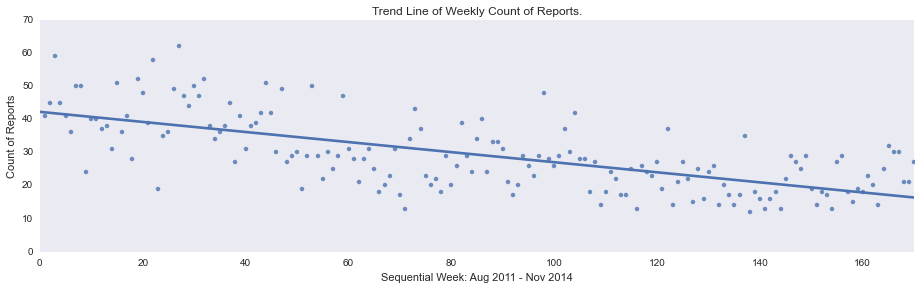

```python
#Swap the order
dfYearWeek = dfRecords.pivot_table(index='Year', columns='Week',values="ID",aggfunc=len)
dfYearWeek = dfYearWeek.stack()

dfYearWeek=dfYearWeek.reset_index()
dfYearWeek.rename(columns={0:'Count'}, inplace=True)
dfYearWeek['Sequence']=(dfYearWeek.index).values+1

#Use seaborn to plot a scatter plot of count of records by week with a trend line.
sns.lmplot('Sequence','Count',dfYearWeek,size=4,aspect=3.25, legend =True)
plt.xlim(0,170)
plt.title("Trend Line of Weekly Count of Reports.")
plt.xlabel("Sequential Week: Aug 2011 - Nov 2014")
plt.ylabel("Count of Reports")
```

- Creating **stacked area chart** use **Matplotlib**
- Calculate percentages and plot

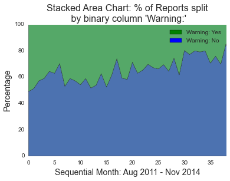

```python
#Create a pivot table
dfWeekYear = dfRecords.pivot_table(index=['Year','Month'],columns='Warning',aggfunc=len)

#Create empty list and add the two columns as arrays.
y=[]
y.append(dfWeekYear['ID','no'].values)
y.append(dfWeekYear['ID','yes'].values)
percent = y/(y[0]+y[1]).astype(float)*100

#Create a sequential array for plotting
x = np.arange(len(dfWeekYear))

plt.stackplot(x, percent)
plt.xlim(0,38)
plt.title("Stacked Area Chart: % of Reports split \n by binary column 'Warning:'",fontsize=16)
plt.xlabel("Sequential Month: Aug 2011 - Nov 2014",fontsize=14)
plt.ylabel("Percentage",fontsize=14)

#For the Legend in Stackplot. Create rectangles and pass to legend object.
import matplotlib.patches as mpatches
p1 = mpatches.Rectangle((0, 0), 1, 1, fc="green")
p2 = mpatches.Rectangle((0, 0), 1, 1, fc="blue")
plt.legend([p1, p2], ['Warning: Yes','Warning: No'])
```

# 4a .Classifcation

- Build a simple Naive Bayes Model using **Description** free text field as input features and **Warning** as target label
- Filter rows to those in English

```python
countDF
```

[output not shown]

```python
from sklearn.feature_extraction.text import CountVectorizer
from sklearn.naive_bayes import MultinomialNB

#Values for document frequencies in percent.
vec1_count = CountVectorizer(min_df=0.001,max_df=0.995)
clf1 = MultinomialNB()
# Extract the predictor and target variables.
X=df['Description:']

#Encode the target variable.
from sklearn.preprocessing import LabelEncoder
le = LabelEncoder()
le.fit(df['Warning:'])
y=le.transform(df['Warning:'])

# Split the data randomly into test and training sets. Set the random state for comparison.
from sklearn import cross_validation
X_train, X_test, y_train, y_test = cross_validation.train_test_split(X,y,test_size=0.3,random_state=79)

from sklearn import pipeline
pipe = pipeline.Pipeline([('vectorizer', vec1_count),('clf', clf1)])

#6# Train the model using 5 fold craiss validation and calculate the scores.
train_scores = cross_validation.cross_val_score(pipe, X_train, y_train, cv=5)
pipe_model=pipe.fit(X_train, y_train)
#must fit to get the vocabulary_
number_features=len(vec1_count.vocabulary_)
test_score=pipe_model.score(X_test,y_test)
```

```python
results_df
```

|  | # Features | 1.Train Acc. | 2.Train std. | 3.Test Score |
| --- | --- | --- | --- | --- |
| 0 | 2268 | 0.732566 | 0.024898 | 0.726122 |

- Visualise the top predictors based on their chi-square statistic
- chi-square currently only variable importance score available in scikit-learn

```python
#feature_select.KBest, feature_select.SelectPercentile for determing the number of features
from sklearn.feature_selection import SelectKBest, chi2

#Feature selection based on select k number of features
fs = SelectKBest(chi2, k=250)
fs.fit(X_train,y_train)


#Return the feature names from the vectorisation
#Get the list of the top 250 as calculated by chi-squared.
chi_index = fs.get_support(indices=False)

#Get feature names and chi-square score.
feature_names = vec.get_feature_names()
chi_score=fs.scores_

#Using index select top 250
from itertools import compress
features_selected=list(compress(feature_names, chi_index))
features_chi_score=list(compress(chi_score,chi_index))

#Tranform the Vectorization to a dense matrix and subset based on the list
#of 250 selected features
X_train_dense=pd.DataFrame(X_train.todense(),columns=vec.get_feature_names())
X_train_select=X_train_dense[features_selected]

#Append the target variable,using the label encoder
X_train_select['words'] = le.inverse_transform(y_train)

#Group and sum on the Target Label, counts the number of documents a word appears in.
grouped=X_train_select.groupby('words')
features_sum=(grouped.sum()).T
features_sum['chi_score']=features_chi_score
```

```python
features_sum[['no','yes','chi_score']].head(n=10)
```

| words | no | yes | chi_score |
| --- | --- | --- | --- |
| black | 203 | 27 | 55.633781 |
| mg | 181 | 26 | 46.631068 |
| nice | 107 | 13 | 31.307648 |
| meth | 2 | 20 | 29.885005 |
| seconds | 104 | 15 | 26.701739 |
| warning | 11 | 30 | 25.859409 |
| marquis | 183 | 46 | 23.020620 |
| sour | 5 | 17 | 17.038636 |
| piperazine | 1 | 11 | 16.747539 |
| mandelin | 70 | 11 | 16.642302 |

```python
import matplotlib.pyplot as plt

#Define color map and figure size.
cm = plt.cm.get_cmap('RdYlBu')
plt.figure(figsize=(18,12))


#Plot the 250 point, size by chi-square score and color by stop.
plt.scatter(x=features_sum['no'], y=features_sum['yes'],
            s=features_sum['chi_score']*25,
            c=features_sum['stop'],cmap=cm,alpha=0.75)

#Plot Title and Axis.
plt.title("Top 250 most predictive words (chi-squared): Frequency Count split by Warning: \
            \n Points coloured if word is English stopword.", fontsize=22)

plt.xlabel("Warning: = no",fontsize=20)
plt.ylabel("Warning: = yes",fontsize=20)
plt.xlim(-5,800)
plt.ylim(-5,400)
#plt.axis('equal')

#Select some features for display label.
data=features_sum[((features_sum["no"] > 200 ) & (features_sum["yes"] >25 ))]
data=data.append(features_sum[((features_sum["no"] < 200) & (features_sum["yes"] >50 ))])
data=data.append(features_sum[(features_sum['chi_score']>14.5)])
data=data.sort(['no','yes'])
```

[figure not shown]

# 4b . PCA & Clustering

- Using the **User Report** free text field as input features, create PCA representation.
- Filter rows to those where the language is English and the Country of origin is USA, Australia, England, Netherlands, Canada, Ireland, Scotland, or Spain - 1458 rows.
- Create a binary occurence vector representation of stemmed words (Porter)
- Normalise vector with tfidf
- 378 features created
- perform PCA and return 2 components
- 3.5% of total variance explained

```python
from sklearn import cluster
from sklearn.decomposition import PCA

#Clustering
k = 3
kmeans = cluster.KMeans(n_clusters=k)
kmeans.fit(data)
clusterDF['Cluster']=kmeans.labels_

#PCA
pca = PCA(n_components=2)
UR_PCA = pca.fit(data.todense()).transform(data.todense())

variance=sum(pca.explained_variance_ratio_)

clusterDF['PC1']=UR_PCA[:,0]
clusterDF['PC2']=UR_PCA[:,1]

print('Explained variance ratio of the first two components: %s'% variance)
```

```
Explained variance ratio of the first two components: 0.0345791983519
```

- create scatter plot of the components
- colour the points according the nominal variables

[figure not shown]

```python
from nltk import pos_tag
clusterDF['Tagged']=(clusterDF['User Report']).map(lambda x: pos_tag(word_tokenize(x)))
clusterDF['Rich_words']=(clusterDF['Tagged']).map(lambda x: ' '.join([y[0].lower() for y in x if y[1] in ['JJ','NN']]))

words1 = ' '.join(clusterDF['Rich_words'][(clusterDF['SC Category']=='mdxx')])
words2 = ' '.join(clusterDF['Rich_words'][(clusterDF['SC Category']=='amphet')])
words3 = ' '.join(clusterDF['Rich_words'][(clusterDF['SC Category']=='unknown')])
```

[figure not shown]